# ARCANE — Regional Beta Calibration: All Regions

ESBL Transmission Rate by Region and Facility Type

ARCANE Project — MESuRS/Cnam

24 August 2026

```r
library(dplyr)
library(ggplot2)
library(tidyr)
library(knitr)
library(kableExtra)
library(scales)
```

```r
# Run compile_region.R first, then knit this document.
COMPILED_FILE <- file.path(
  "C:/Users/octariar/OneDrive - LECNAM/Documents/GitHub/arcane-temporal-network-new/optim_cluster_jobs",
  "Outputs", "region_cluster",
  "compiled", "compiled_region.rds"
)
if (!file.exists(COMPILED_FILE))
  stop("Run compile_region.R first.\nExpected: ", COMPILED_FILE)

compiled      <- readRDS(COMPILED_FILE)
all_summaries <- compiled$all_summaries
all_run_sse   <- compiled$all_run_sse
beta_wide     <- compiled$beta_wide
sse_summary   <- compiled$sse_summary
results       <- compiled$results
all_regions   <- compiled$regions
n_regions     <- compiled$n_regions

# Colour palette for facility types
type_colours <- c(
  "General public hospital"         = "#0057B8",
  "University hospital"             = "#F5A623",
  "Private for profit hospital"     = "#E74C3C",
  "Private not-for-profit hospital" = "#9B1D8A",
  "Rehabilitation hospital"         = "#C1392B",
  "Cancer centre (CLCC)"            = "#2ECC71",
  "MCO"     = "#0057B8", "SSR"     = "#C1392B",
  "MCO/SSR" = "#9B1D8A", "PSY"     = "#F5A623",
  "HAD"     = "#00B4D8", "Unknown" = "#555555"
)
```

```r
# Recompute with normalised metrics so Rmd works regardless of compile version
sse_summary <- all_summaries %>%
  group_by(region, H_region, sse_total) %>%
  summarise(n_types = n(), .groups = "drop") %>%
  mutate(
    sse_per_type = round(sse_total / n_types, 6),
    mape = sapply(region, function(r) {
      d <- filter(all_summaries, region == r)
      round(mean(abs(d$diff / d$incidence_obs) * 100, na.rm = TRUE), 2)
    }),
    r2 = sapply(region, function(r) {
      d <- filter(all_summaries, region == r)
      if (nrow(d) < 2) return(NA_real_)
      round(cor(d$incidence_obs, d$incidence_sim_mean,
                use = "complete.obs")^2, 4)
    })
  ) %>%
  arrange(mape)
```

# Overview

This report covers **12 French administrative regions**, each calibrated independently using a stochastic SIS network model on the PMSI inter-hospital transfer network. Beta (β) — the daily within-hospital ESBL transmission rate — is estimated separately per **facility type** within each region.

# Part 1 — Cross-regional comparison

*Each plot in this section shows all 12 regions together, making it easy to spot regional patterns, outliers, and types that are hard to calibrate.*

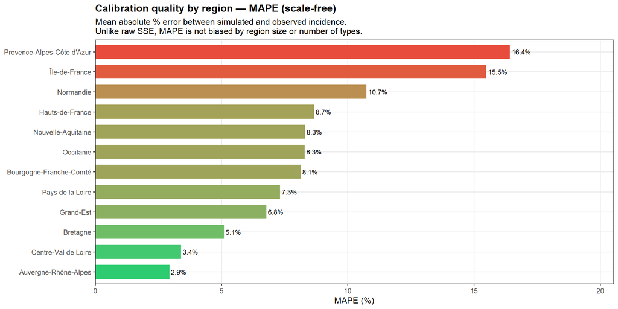

```r
sse_summary %>%
  mutate(region = gsub("_", " ", region)) %>%
  ggplot(aes(x = reorder(region, mape), y = mape, fill = mape)) +
  geom_col(width = 0.7) +
  geom_text(aes(label = paste0(round(mape, 1), "%")), hjust = -0.1, size = 3.3) +
  scale_fill_gradient(low = "#2ecc71", high = "#e74c3c", guide = "none") +
  scale_y_continuous(expand = expansion(mult = c(0, 0.25))) +
  coord_flip() +
  labs(
    title    = "Calibration quality by region — MAPE (scale-free)",
    subtitle = paste0("Mean absolute % error between simulated and observed incidence.\n",
                      "Unlike raw SSE, MAPE is not biased by region size or number of types."),
    x = NULL, y = "MAPE (%)"
  ) +
  theme_bw(base_size = 12) +
  theme(plot.title = element_text(face = "bold"),
        panel.grid.minor = element_blank())
```

## 1.2 Beta by region and facility type (heatmap)

- **Patterns across columns** (types): if one type consistently has higher β across most regions, that type has inherently faster transmission nationally
- **Patterns across rows** (regions): if one region has consistently higher β across all types, that region may have higher overall transmission pressure (hygiene infrastructure, antibiotic pressure, patient case mix)
- **Missing cells**: the type was absent or had no SPARES data in that region

[figure not shown]

```r
heatmap_data <- all_summaries %>%
  mutate(region = gsub("_", " ", region)) %>%
  filter(!is.na(beta))

ggplot(heatmap_data,
       aes(x = type, y = reorder(region, sse_total),
           fill = beta)) +
  geom_tile(colour = "white", linewidth = 0.5) +
  geom_text(aes(label = formatC(beta, format = "e", digits = 1)),
            size = 2.8) +
  scale_fill_viridis_c(name = "β (per day)", option = "plasma",
                       trans = "log10",
                       labels = scales::scientific) +
  labs(
    title    = "Optimal β per facility type × region",
    subtitle = "Log10 colour scale  |  Empty = no SPARES data for this type in this region",
    x = "Facility type", y = "Region (sorted by SSE, best at top)"
  ) +
  theme_bw(base_size = 11) +
  theme(plot.title    = element_text(face = "bold"),
        axis.text.x   = element_text(angle = 35, hjust = 1),
        legend.position = "right",
        panel.grid    = element_blank())
```

## 1.3 Beta distribution across regions by facility type

**What this shows:** For each facility type, the spread of β estimates across all regions — shown as a boxplot with individual region points. Wide boxes = high regional variability (β differs a lot by region). Narrow boxes = the national signal is consistent.

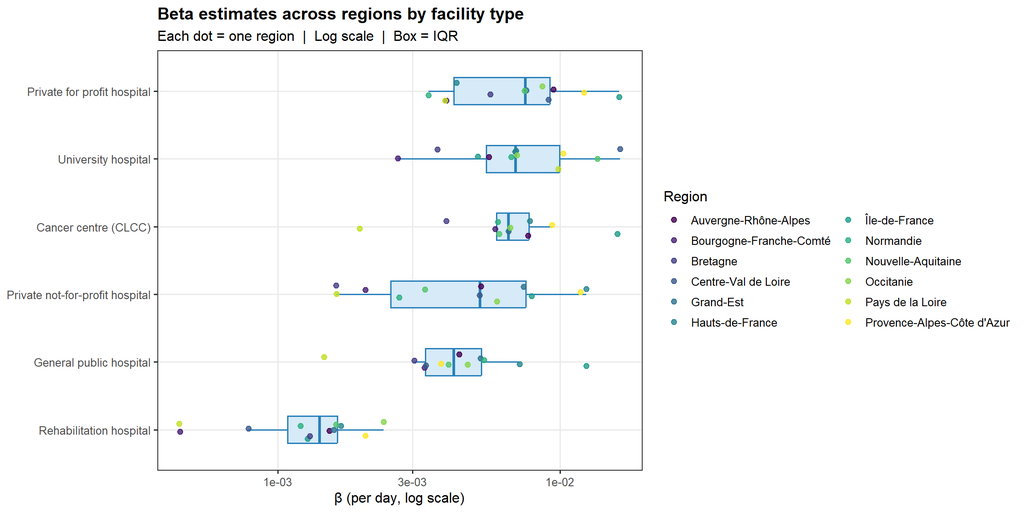

```r
all_summaries %>%
  filter(!is.na(beta)) %>%
  mutate(region = gsub("_", " ", region)) %>%
  ggplot(aes(x = reorder(type, beta, FUN = median), y = beta)) +
  geom_boxplot(width = 0.4, outlier.shape = NA,
               fill = "#d6eaf8", colour = "#2980b9", linewidth = 0.6) +
  geom_jitter(aes(colour = gsub("_", " ", region)),
              width = 0.15, size = 2, alpha = 0.8) +
  scale_y_log10(labels = scales::scientific) +
  scale_colour_viridis_d(name = "Region", guide = guide_legend(ncol = 2)) +
  labs(
    title    = "Beta estimates across regions by facility type",
    subtitle = "Each dot = one region  |  Log scale  |  Box = IQR",
    x = NULL, y = "β (per day, log scale)"
  ) +
  coord_flip() +
  theme_bw(base_size = 12) +
  theme(plot.title      = element_text(face = "bold"),
        legend.position = "right",
        panel.grid.minor = element_blank())
```

## 1.4 Observed vs simulated incidence — all regions, all types

**What this shows:** Every region × type combination in one scatter plot. Points on the dashed diagonal = perfect fit. Colour = region, shape = facility type. This is the most comprehensive single view of calibration quality.

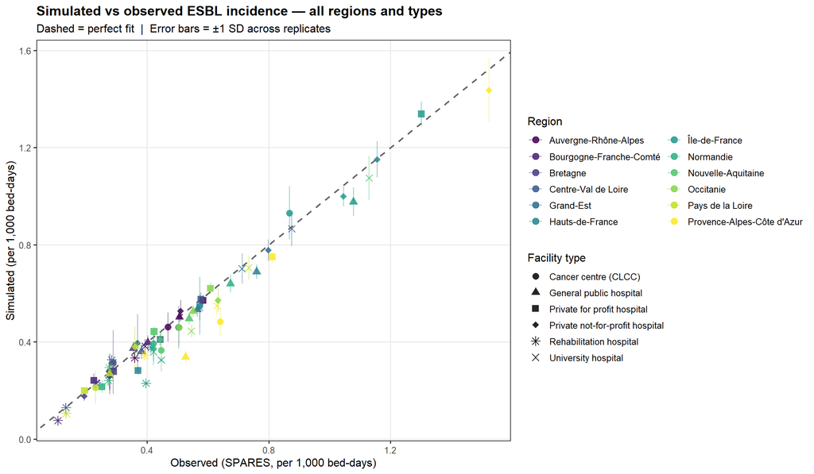

```r
all_summaries %>%
  filter(!is.na(incidence_obs) & !is.na(incidence_sim_mean)) %>%
  mutate(region = gsub("_", " ", region)) %>%
  ggplot(aes(x = incidence_obs, y = incidence_sim_mean,
             colour = region)) +
  geom_abline(slope = 1, intercept = 0, linetype = "dashed",
              colour = "grey40", linewidth = 0.8) +
  geom_errorbar(aes(ymin = pmax(incidence_sim_mean - incidence_sim_sd, 0),
                    ymax = incidence_sim_mean + incidence_sim_sd),
                width = 0, alpha = 0.35, linewidth = 0.6) +
  geom_point(aes(shape = type), size = 3, alpha = 0.85) +
  scale_colour_viridis_d(name = "Region",
                         guide = guide_legend(ncol = 2, override.aes = list(size=3))) +
  scale_shape_manual(values = c(16,17,15,18,8,4,3,1,0,2,5,6)[
    seq_along(unique(all_summaries$type))],
    name = "Facility type") +
  labs(
    title    = "Simulated vs observed ESBL incidence — all regions and types",
    subtitle = "Dashed = perfect fit  |  Error bars = ±1 SD across replicates",
    x = "Observed (SPARES, per 1,000 bed-days)",
    y = "Simulated (per 1,000 bed-days)"
  ) +
  theme_bw(base_size = 12) +
  theme(plot.title = element_text(face = "bold"),
        legend.position = "right",
        panel.grid.minor = element_blank())
```

## 1.5 Observed vs simulated — faceted by region

**What this shows:** Same data as above but split into one panel per region, making it easier to assess the fit for each region individually.

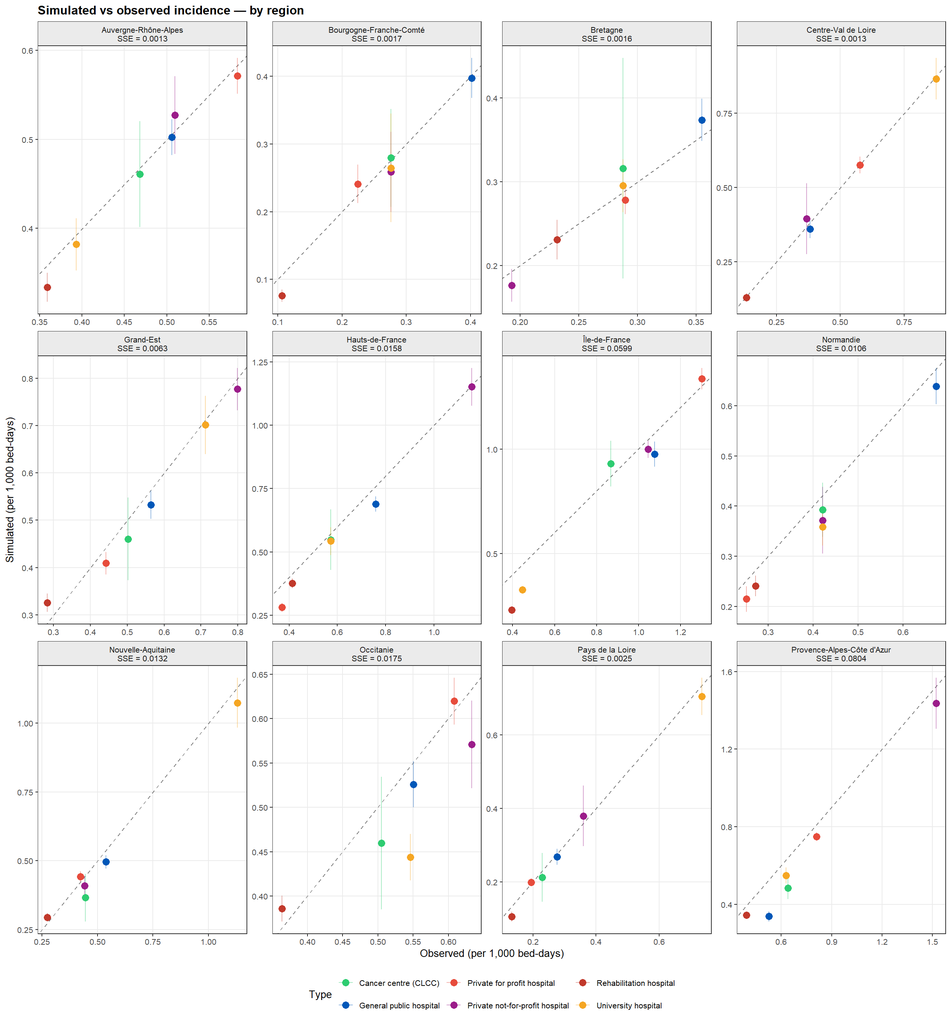

```r
all_summaries %>%
  filter(!is.na(incidence_obs) & !is.na(incidence_sim_mean)) %>%
  mutate(region_label = paste0(gsub("_", " ", region),
                                "\nSSE = ", round(sse_total, 4))) %>%
  ggplot(aes(x = incidence_obs, y = incidence_sim_mean,
             colour = type)) +
  geom_abline(slope = 1, intercept = 0, linetype = "dashed",
              colour = "grey50") +
  geom_errorbar(aes(ymin = pmax(incidence_sim_mean - incidence_sim_sd, 0),
                    ymax = incidence_sim_mean + incidence_sim_sd),
                width = 0, alpha = 0.4) +
  geom_point(size = 3) +
  facet_wrap(~ region_label, ncol = 4, scales = "free") +
  scale_colour_manual(values = type_colours, na.value = "#555555",
                      name = "Type") +
  labs(
    title = "Simulated vs observed incidence — by region",
    x = "Observed (per 1,000 bed-days)",
    y = "Simulated (per 1,000 bed-days)"
  ) +
  theme_bw(base_size = 10) +
  theme(plot.title       = element_text(face = "bold"),
        legend.position  = "bottom",
        strip.background = element_rect(fill = "grey92"),
        panel.grid.minor = element_blank())
```

## 1.6 Percentage error by region and type

**What this shows:** How far off the simulation is for each region × type, as a percentage of the observed rate. Red = over-estimate, blue = under-estimate, white = near-perfect. Reveals systematic biases — e.g. if a type is always under-estimated in all regions, the model may be missing something structural.

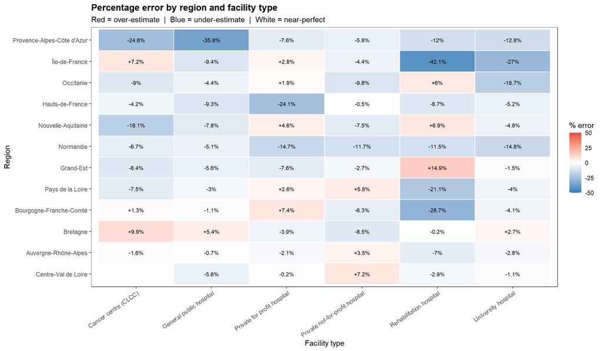

```r
all_summaries %>%
  mutate(pct_error = 100 * diff / incidence_obs,
         region    = gsub("_", " ", region)) %>%
  filter(!is.na(pct_error)) %>%
  ggplot(aes(x = type, y = reorder(region, sse_total),
             fill = pct_error)) +
  geom_tile(colour = "white", linewidth = 0.5) +
  geom_text(aes(label = paste0(ifelse(pct_error > 0, "+", ""),
                               round(pct_error, 1), "%")),
            size = 2.8) +
  scale_fill_gradient2(low = "#2980b9", mid = "white", high = "#e74c3c",
                       midpoint = 0, limits = c(-50, 50), oob = scales::squish,
                       name = "% error") +
  labs(
    title    = "Percentage error by region and facility type",
    subtitle = "Red = over-estimate  |  Blue = under-estimate  |  White = near-perfect",
    x = "Facility type", y = "Region"
  ) +
  theme_bw(base_size = 11) +
  theme(plot.title   = element_text(face = "bold"),
        axis.text.x  = element_text(angle = 35, hjust = 1),
        panel.grid   = element_blank())
```

## 1.7 Beta variability across regions by type

**What this shows:** How consistent β is across regions for each facility type. CV% = coefficient of variation (standard deviation / mean × 100). A high CV% means β varies a lot between regions — the national estimate may be masking important regional differences.

```r
compiled$beta_type_stats %>%
  rename(
    "Facility type"        = type,
    "Regions with data"    = n_regions,
    "Min β"                = beta_min,
    "Median β"             = beta_med,
    "Max β"                = beta_max,
    "CV% (regional spread)"= beta_cv
  ) %>%
  kable(align = c("l","c","r","r","r","r")) %>%
  kable_styling(bootstrap_options = c("striped","hover","condensed"),
                full_width = TRUE) %>%
  footnote(general = paste0(
    "CV% = standard deviation / mean × 100 across regions. ",
    "Low CV% = β is consistent across regions (national estimate is reliable). ",
    "High CV% = large regional variation (region-specific β adds important nuance)."
  ))
```

| Facility type | Regions with data | Min β | Median β | Max β | CV% (regional spread) |
| --- | --- | --- | --- | --- | --- |
| Cancer centre (CLCC) | 11 | 0.001945 | 0.006565 | 0.015966 | 49.9 |
| General public hospital | 12 | 0.001460 | 0.004208 | 0.012377 | 57.0 |
| Private for profit hospital | 12 | 0.003422 | 0.007543 | 0.016178 | 49.9 |
| Private not-for-profit hospital | 12 | 0.001608 | 0.005213 | 0.012395 | 66.4 |
| Rehabilitation hospital | 12 | 0.000447 | 0.001411 | 0.002369 | 43.1 |
| University hospital | 12 | 0.002660 | 0.006963 | 0.016334 | 50.5 |

Note:  
CV% = standard deviation / mean × 100 across regions. Low CV% = β is consistent across regions (national estimate is reliable). High CV% = large regional variation (region-specific β adds important nuance).

## 1.8 Hospitals per region

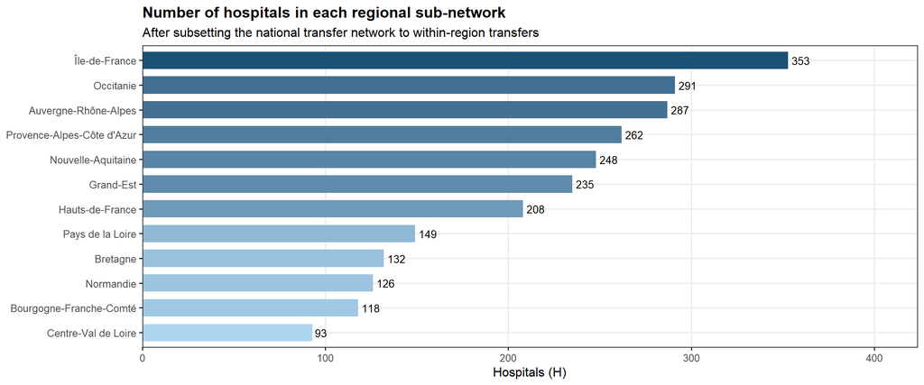

```r
all_summaries %>%
  distinct(region, H_region) %>%
  mutate(region = gsub("_", " ", region)) %>%
  ggplot(aes(x = reorder(region, H_region), y = H_region,
             fill = H_region)) +
  geom_col(width = 0.7) +
  geom_text(aes(label = H_region), hjust = -0.2, size = 3.5) +
  scale_fill_gradient(low = "#aed6f1", high = "#1a5276", guide = "none") +
  scale_y_continuous(expand = expansion(mult = c(0, 0.2))) +
  coord_flip() +
  labs(title = "Number of hospitals in each regional sub-network",
       subtitle = "After subsetting the national transfer network to within-region transfers",
       x = NULL, y = "Hospitals (H)") +
  theme_bw(base_size = 12) +
  theme(plot.title = element_text(face = "bold"),
        panel.grid.minor = element_blank())
```

## 1.8 National beta summary per facility type

**What this shows:** A single national β estimate per facility type, synthesising all regional calibrations into one number with appropriate uncertainty.

**Weighted geometric mean** (weights = number of hospitals per region): regions with more hospitals contribute more because their beta estimate is based on more data and is therefore more reliable.

**Why geometric mean:** Beta is always positive and right-skewed across regions — the geometric mean (mean of log-beta, back-transformed) is the natural summary for a rate parameter.

**95% CI from bootstrap:** With only 12 regions, a normal-distribution CI is unreliable. The CI is computed by resampling regions 2,000 times in log-space.

**Weighted median + IQR:** Shown alongside as a robustness check — insensitive to outlier regions.

```r
# Computed here so the table works regardless of compile_region.R version
set.seed(42)
n_boot <- 2000

weighted_beta_summary <- all_summaries %>%
  filter(!is.na(beta), !is.na(H_region), beta > 0) %>%
  group_by(type) %>%
  group_modify(function(d, key) {
    w     <- d$H_region
    log_b <- log(d$beta)
    n     <- nrow(d)
    wgm   <- exp(sum(w * log_b) / sum(w))
    w_norm <- pmax(round(w / min(w) * 10), 1L)
    b_rep  <- rep(d$beta, w_norm)
    wmed   <- median(b_rep)
    wq25   <- quantile(b_rep, 0.25)
    wq75   <- quantile(b_rep, 0.75)
    boot_wgm <- replicate(n_boot, {
      idx <- sample(seq_len(n), n, replace = TRUE)
      bd  <- d[idx, ]; wd <- w[idx]
      exp(sum(wd * log(bd$beta)) / sum(wd))
    })
    data.frame(
      n_regions    = n,
      total_weight = round(sum(w)),
      wgm          = round(wgm,                       6),
      ci_lo_95     = round(quantile(boot_wgm, 0.025), 6),
      ci_hi_95     = round(quantile(boot_wgm, 0.975), 6),
      w_median     = round(wmed, 6),
      w_iqr_lo     = round(wq25, 6),
      w_iqr_hi     = round(wq75, 6),
      stringsAsFactors = FALSE
    )
  }) %>%
  ungroup()
```

```r
weighted_beta_summary %>%
  mutate(
    `Weighted geom. mean` = formatC(wgm,      format = "e", digits = 3),
    `95% CI`              = paste0("[", formatC(ci_lo_95, format = "e", digits = 2),
                                    " – ",
                                    formatC(ci_hi_95, format = "e", digits = 2), "]"),
    `Weighted median`     = formatC(w_median, format = "e", digits = 3),
    `IQR`                 = paste0("[", formatC(w_iqr_lo, format = "e", digits = 2),
                                    " – ",
                                    formatC(w_iqr_hi, format = "e", digits = 2), "]")
  ) %>%
  select(type, n_regions, total_weight,
         `Weighted geom. mean`, `95% CI`, `Weighted median`, `IQR`) %>%
  rename("Facility type"             = type,
         "Regions"                   = n_regions,
         "Total hospitals (weight)"  = total_weight) %>%
  kable(align = c("l","c","r","r","r","r","r")) %>%
  kable_styling(bootstrap_options = c("striped","hover"), full_width = TRUE) %>%
  footnote(general = paste0(
    "Weighted geometric mean: exp(sum(w_r x log(beta_r)) / sum(w_r)) where w_r = ",
    "hospitals in region r for that type. ",
    "95% CI from 2,000 bootstrap resamplings of regions in log-space. ",
    "Weighted median and IQR computed by repeating each region proportional to its weight."
  ))
```

| Facility type | Regions | Total hospitals (weight) | Weighted geom. mean | 95% CI | Weighted median | IQR |
| --- | --- | --- | --- | --- | --- | --- |
| Cancer centre (CLCC) | 11 | 2409 | 7.141e-03 | [5.12e-03 – 9.62e-03] | 6.665e-03 | [6.08e-03 – 9.37e-03] |
| General public hospital | 12 | 2502 | 4.799e-03 | [3.52e-03 – 6.53e-03] | 4.397e-03 | [3.78e-03 – 5.38e-03] |
| Private for profit hospital | 12 | 2502 | 7.817e-03 | [5.71e-03 – 1.02e-02] | 8.662e-03 | [5.67e-03 – 9.47e-03] |
| Private not-for-profit hospital | 12 | 2502 | 5.281e-03 | [3.56e-03 – 7.24e-03] | 5.985e-03 | [3.32e-03 – 7.94e-03] |
| Rehabilitation hospital | 12 | 2502 | 1.375e-03 | [1.04e-03 – 1.70e-03] | 1.525e-03 | [1.27e-03 – 1.67e-03] |
| University hospital | 12 | 2502 | 7.040e-03 | [5.69e-03 – 8.89e-03] | 6.938e-03 | [5.61e-03 – 9.85e-03] |

Note:  
Weighted geometric mean: exp(sum(w_r x log(beta_r)) / sum(w_r)) where w_r = hospitals in region r for that type. 95% CI from 2,000 bootstrap resamplings of regions in log-space. Weighted median and IQR computed by repeating each region proportional to its weight.

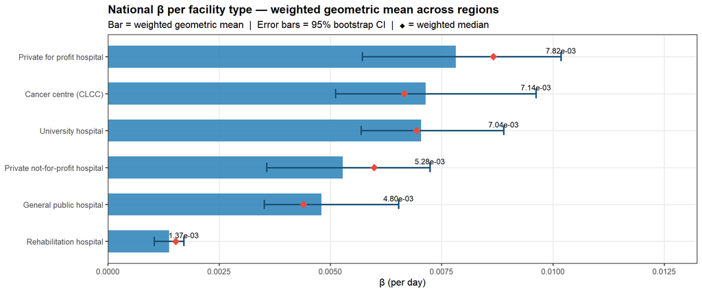

```r
weighted_beta_summary %>%
  ggplot(aes(x = reorder(type, wgm), y = wgm)) +
  geom_col(fill = "#2980b9", width = 0.6, alpha = 0.85) +
  geom_errorbar(aes(ymin = ci_lo_95, ymax = ci_hi_95),
                width = 0.25, linewidth = 0.9, colour = "#1a5276") +
  geom_point(aes(y = w_median), shape = 18, size = 4, colour = "#e74c3c") +
  geom_text(aes(label = formatC(wgm, format = "e", digits = 2),
                y = ci_hi_95),
            vjust = -0.6, size = 3.3) +
  scale_y_continuous(expand = expansion(mult = c(0, 0.3))) +
  coord_flip() +
  labs(
    title    = "National β per facility type — weighted geometric mean across regions",
    subtitle = paste0("Bar = weighted geometric mean  |  ",
                      "Error bars = 95% bootstrap CI  |  ",
                      "◆ = weighted median"),
    x = NULL, y = "β (per day)"
  ) +
  theme_bw(base_size = 12) +
  theme(plot.title = element_text(face = "bold"),
        panel.grid.minor = element_blank())
```

# Part 2 — Individual region reports

*One section per region with the same diagnostics as the regional Rmd.*

## Île-de-France

**Hospitals in region:** 353 | **SSE:** 0.059897 | **Types:** Cancer centre (CLCC), General public hospital, Private for profit hospital, Private not-for-profit hospital, Rehabilitation hospital, University hospital

### Observed vs simulated incidence

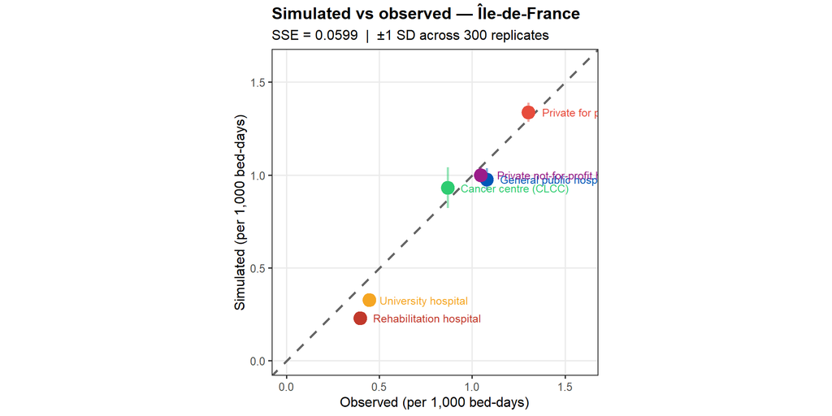

### Beta estimates

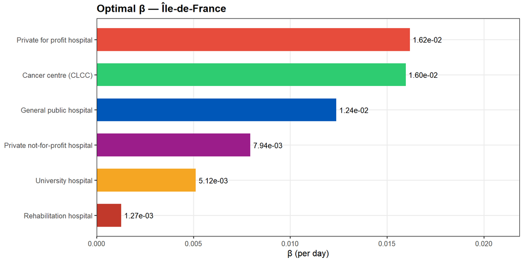

### Numerical summary

| Type | β | Observed | Sim mean | Sim SD | % error | SSE |
| --- | --- | --- | --- | --- | --- | --- |
| Cancer centre (CLCC) | 0.0160 | 0.8683 | 0.9305 | 0.1094 | 7.2 | 0.0039 |
| General public hospital | 0.0124 | 1.0779 | 0.9766 | 0.0601 | -9.4 | 0.0103 |
| Private for profit hospital | 0.0162 | 1.3019 | 1.3382 | 0.0511 | 2.8 | 0.0013 |
| Private not-for-profit hospital | 0.0079 | 1.0452 | 0.9992 | 0.0409 | -4.4 | 0.0021 |
| Rehabilitation hospital | 0.0013 | 0.3961 | 0.2292 | 0.0088 | -42.1 | 0.0279 |
| University hospital | 0.0051 | 0.4460 | 0.3258 | 0.0119 | -27.0 | 0.0145 |

## Auvergne-Rhône-Alpes

**Hospitals in region:** 287 | **SSE:** 0.001285 | **Types:** Cancer centre (CLCC), General public hospital, Private for profit hospital, Private not-for-profit hospital, Rehabilitation hospital, University hospital

### Observed vs simulated incidence

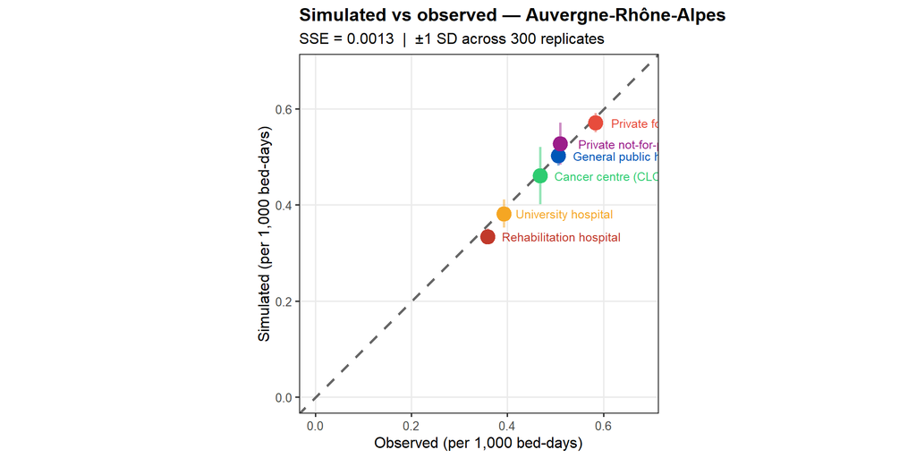

### Beta estimates

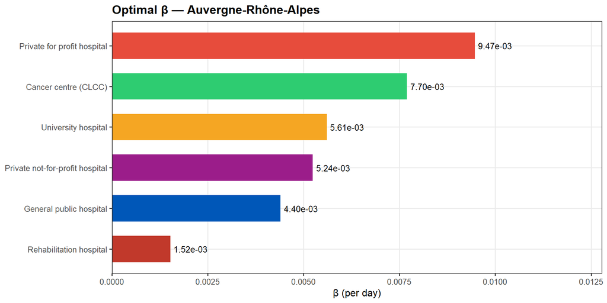

### Numerical summary

| Type | β | Observed | Sim mean | Sim SD | % error | SSE |
| --- | --- | --- | --- | --- | --- | --- |
| Cancer centre (CLCC) | 0.0077 | 0.4684 | 0.4609 | 0.0596 | -1.6 | 1e-04 |
| General public hospital | 0.0044 | 0.5058 | 0.5025 | 0.0202 | -0.7 | 0e+00 |
| Private for profit hospital | 0.0095 | 0.5833 | 0.5713 | 0.0201 | -2.1 | 1e-04 |
| Private not-for-profit hospital | 0.0052 | 0.5095 | 0.5275 | 0.0436 | 3.5 | 3e-04 |
| Rehabilitation hospital | 0.0015 | 0.3590 | 0.3339 | 0.0164 | -7.0 | 6e-04 |
| University hospital | 0.0056 | 0.3930 | 0.3820 | 0.0292 | -2.8 | 1e-04 |

## Bourgogne-Franche-Comté

**Hospitals in region:** 118 | **SSE:** 0.001672 | **Types:** Cancer centre (CLCC), General public hospital, Private for profit hospital, Private not-for-profit hospital, Rehabilitation hospital, University hospital

### Observed vs simulated incidence

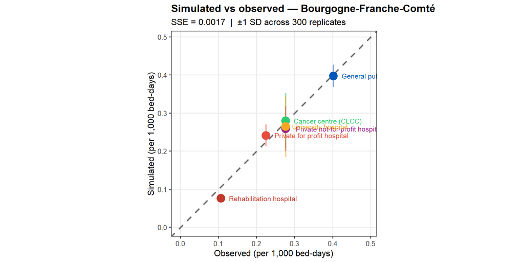

### Beta estimates

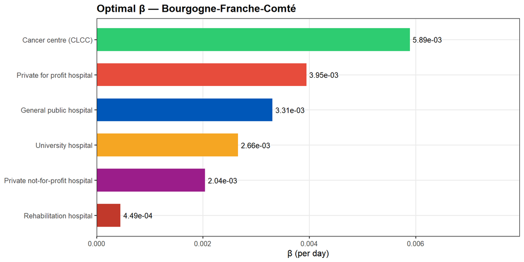

### Numerical summary

| Type | β | Observed | Sim mean | Sim SD | % error | SSE |
| --- | --- | --- | --- | --- | --- | --- |
| Cancer centre (CLCC) | 0.0059 | 0.2761 | 0.2796 | 0.0723 | 1.3 | 0e+00 |
| General public hospital | 0.0033 | 0.4019 | 0.3976 | 0.0294 | -1.1 | 0e+00 |
| Private for profit hospital | 0.0039 | 0.2244 | 0.2411 | 0.0285 | 7.4 | 3e-04 |
| Private not-for-profit hospital | 0.0020 | 0.2761 | 0.2588 | 0.0592 | -6.3 | 3e-04 |
| Rehabilitation hospital | 0.0004 | 0.1065 | 0.0760 | 0.0091 | -28.7 | 9e-04 |
| University hospital | 0.0027 | 0.2761 | 0.2647 | 0.0801 | -4.1 | 1e-04 |

## Bretagne

**Hospitals in region:** 132 | **SSE:** 0.00164 | **Types:** Cancer centre (CLCC), General public hospital, Private for profit hospital, Private not-for-profit hospital, Rehabilitation hospital, University hospital

### Observed vs simulated incidence

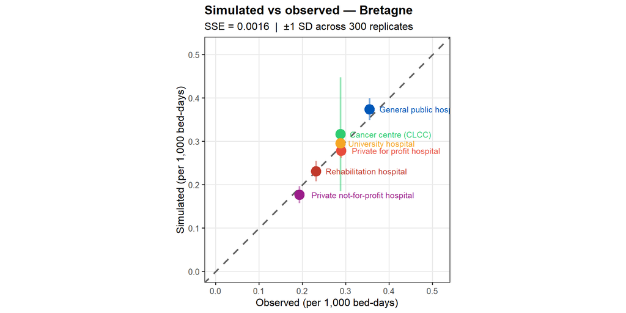

### Beta estimates

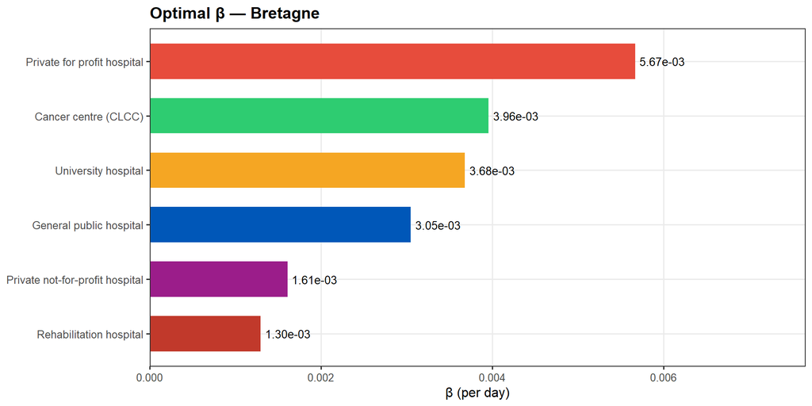

### Numerical summary

| Type | β | Observed | Sim mean | Sim SD | % error | SSE |
| --- | --- | --- | --- | --- | --- | --- |
| Cancer centre (CLCC) | 0.0040 | 0.2876 | 0.3162 | 0.1313 | 9.9 | 8e-04 |
| General public hospital | 0.0030 | 0.3546 | 0.3738 | 0.0251 | 5.4 | 4e-04 |
| Private for profit hospital | 0.0057 | 0.2896 | 0.2782 | 0.0169 | -3.9 | 1e-04 |
| Private not-for-profit hospital | 0.0016 | 0.1929 | 0.1765 | 0.0196 | -8.5 | 3e-04 |
| Rehabilitation hospital | 0.0013 | 0.2314 | 0.2311 | 0.0237 | -0.2 | 0e+00 |
| University hospital | 0.0037 | 0.2876 | 0.2955 | 0.0316 | 2.7 | 1e-04 |

## Centre-Val de Loire

**Hospitals in region:** 93 | **SSE:** 0.001273 | **Types:** General public hospital, Private for profit hospital, Private not-for-profit hospital, Rehabilitation hospital, University hospital

### Observed vs simulated incidence

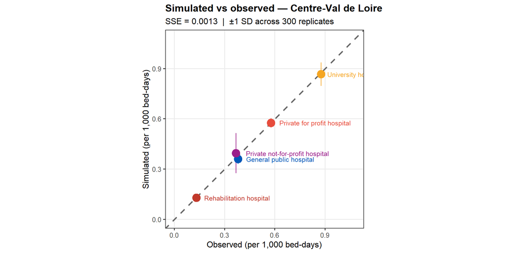

### Beta estimates

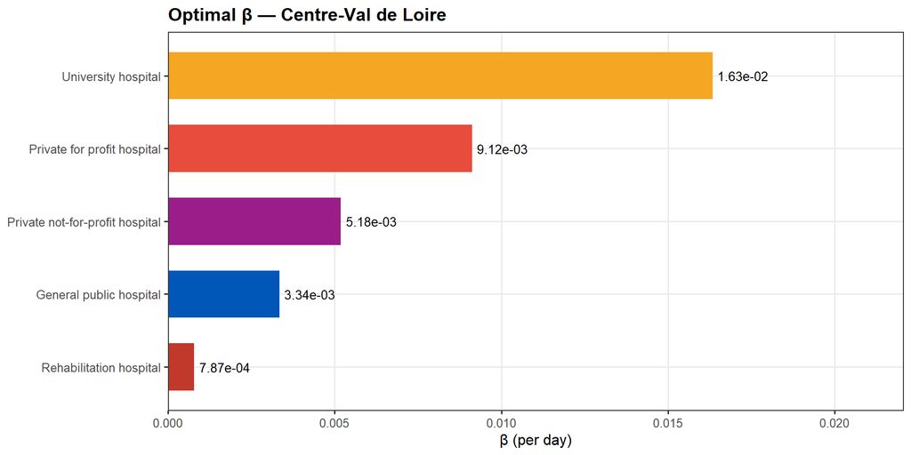

### Numerical summary

| Type | β | Observed | Sim mean | Sim SD | % error | SSE |
| --- | --- | --- | --- | --- | --- | --- |
| General public hospital | 0.0033 | 0.3812 | 0.3598 | 0.0301 | -5.6 | 5e-04 |
| Private for profit hospital | 0.0091 | 0.5768 | 0.5757 | 0.0280 | -0.2 | 0e+00 |
| Private not-for-profit hospital | 0.0052 | 0.3681 | 0.3947 | 0.1192 | 7.2 | 7e-04 |
| Rehabilitation hospital | 0.0008 | 0.1327 | 0.1288 | 0.0143 | -2.9 | 0e+00 |
| University hospital | 0.0163 | 0.8754 | 0.8659 | 0.0700 | -1.1 | 1e-04 |

## Grand-Est

**Hospitals in region:** 235 | **SSE:** 0.006268 | **Types:** Cancer centre (CLCC), General public hospital, Private for profit hospital, Private not-for-profit hospital, Rehabilitation hospital, University hospital

### Observed vs simulated incidence

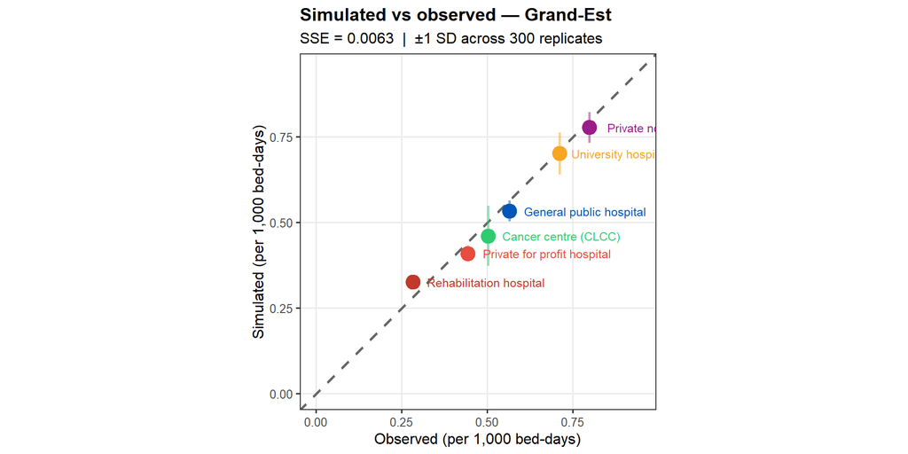

### Beta estimates

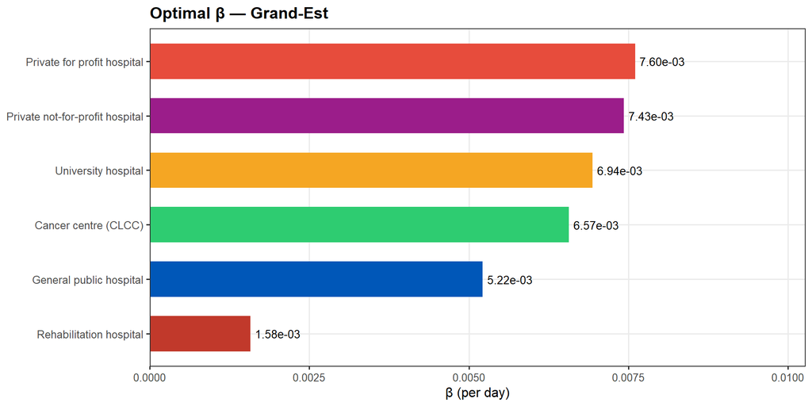

### Numerical summary

| Type | β | Observed | Sim mean | Sim SD | % error | SSE |
| --- | --- | --- | --- | --- | --- | --- |
| Cancer centre (CLCC) | 0.0066 | 0.5027 | 0.4604 | 0.0875 | -8.4 | 0.0018 |
| General public hospital | 0.0052 | 0.5643 | 0.5329 | 0.0298 | -5.6 | 0.0010 |
| Private for profit hospital | 0.0076 | 0.4428 | 0.4092 | 0.0237 | -7.6 | 0.0011 |
| Private not-for-profit hospital | 0.0074 | 0.7988 | 0.7771 | 0.0447 | -2.7 | 0.0005 |
| Rehabilitation hospital | 0.0016 | 0.2833 | 0.3256 | 0.0190 | 14.9 | 0.0018 |
| University hospital | 0.0069 | 0.7118 | 0.7013 | 0.0615 | -1.5 | 0.0001 |

## Hauts-de-France

**Hospitals in region:** 208 | **SSE:** 0.015758 | **Types:** Cancer centre (CLCC), General public hospital, Private for profit hospital, Private not-for-profit hospital, Rehabilitation hospital, University hospital

### Observed vs simulated incidence

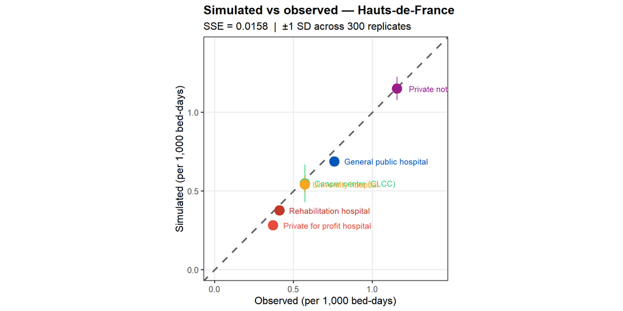

### Beta estimates

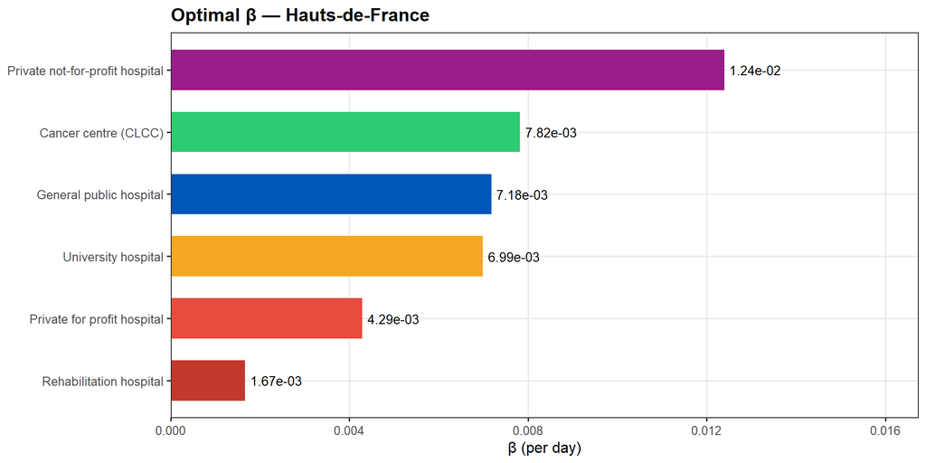

### Numerical summary

| Type | β | Observed | Sim mean | Sim SD | % error | SSE |
| --- | --- | --- | --- | --- | --- | --- |
| Cancer centre (CLCC) | 0.0078 | 0.5725 | 0.5482 | 0.1195 | -4.2 | 0.0006 |
| General public hospital | 0.0072 | 0.7595 | 0.6887 | 0.0301 | -9.3 | 0.0050 |
| Private for profit hospital | 0.0043 | 0.3705 | 0.2813 | 0.0170 | -24.1 | 0.0079 |
| Private not-for-profit hospital | 0.0124 | 1.1566 | 1.1512 | 0.0746 | -0.5 | 0.0000 |
| Rehabilitation hospital | 0.0017 | 0.4126 | 0.3768 | 0.0199 | -8.7 | 0.0013 |
| University hospital | 0.0070 | 0.5725 | 0.5426 | 0.0544 | -5.2 | 0.0009 |

## Normandie

**Hospitals in region:** 126 | **SSE:** 0.010603 | **Types:** Cancer centre (CLCC), General public hospital, Private for profit hospital, Private not-for-profit hospital, Rehabilitation hospital, University hospital

### Observed vs simulated incidence

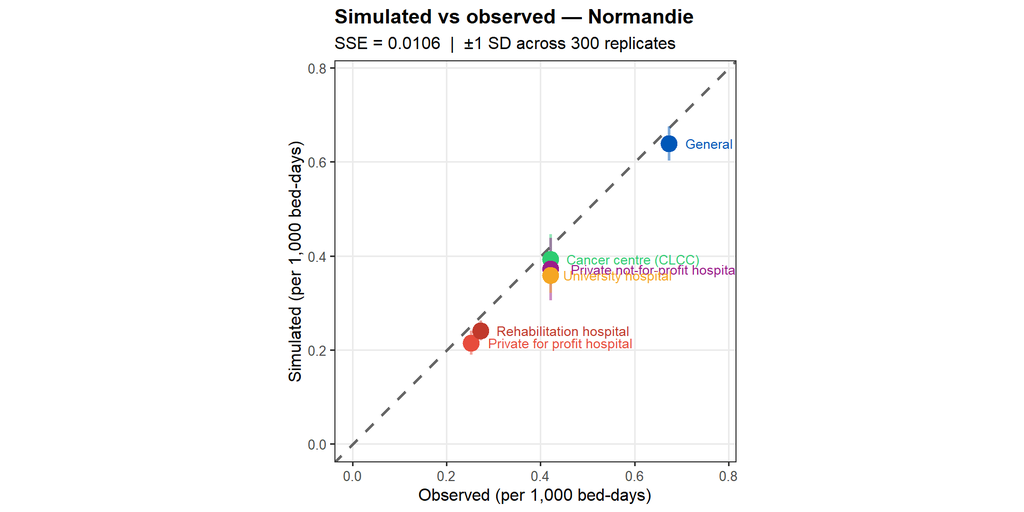

### Beta estimates

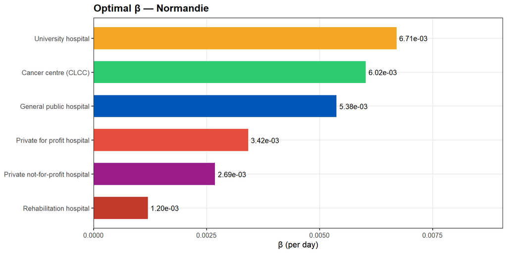

### Numerical summary

| Type | β | Observed | Sim mean | Sim SD | % error | SSE |
| --- | --- | --- | --- | --- | --- | --- |
| Cancer centre (CLCC) | 0.0060 | 0.4210 | 0.3928 | 0.0538 | -6.7 | 0.0008 |
| General public hospital | 0.0054 | 0.6735 | 0.6393 | 0.0363 | -5.1 | 0.0012 |
| Private for profit hospital | 0.0034 | 0.2519 | 0.2149 | 0.0255 | -14.7 | 0.0014 |
| Private not-for-profit hospital | 0.0027 | 0.4210 | 0.3717 | 0.0667 | -11.7 | 0.0024 |
| Rehabilitation hospital | 0.0012 | 0.2723 | 0.2409 | 0.0208 | -11.5 | 0.0010 |
| University hospital | 0.0067 | 0.4210 | 0.3588 | 0.0378 | -14.8 | 0.0039 |

## Nouvelle-Aquitaine

**Hospitals in region:** 248 | **SSE:** 0.01318 | **Types:** Cancer centre (CLCC), General public hospital, Private for profit hospital, Private not-for-profit hospital, Rehabilitation hospital, University hospital

### Observed vs simulated incidence

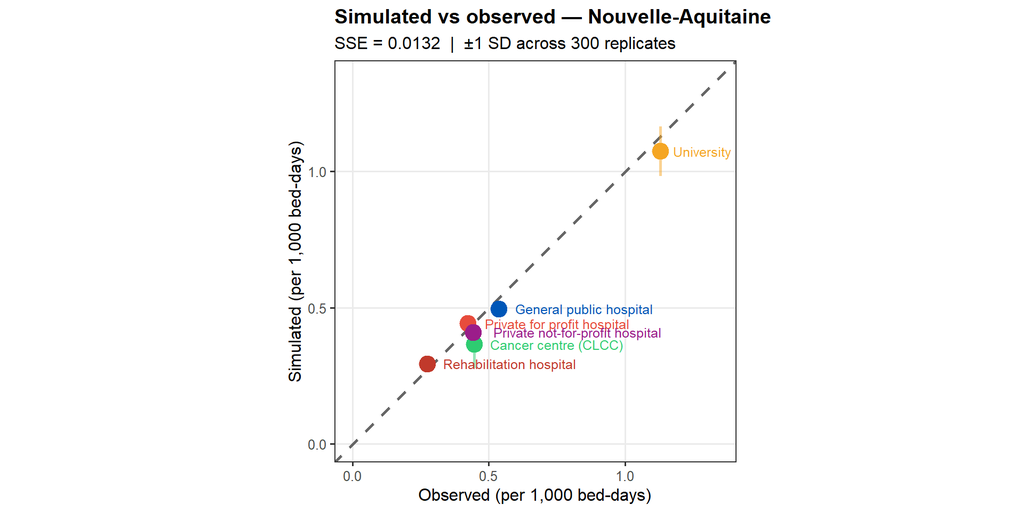

### Beta estimates

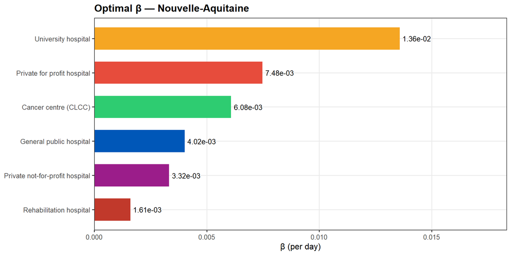

### Numerical summary

| Type | β | Observed | Sim mean | Sim SD | % error | SSE |
| --- | --- | --- | --- | --- | --- | --- |
| Cancer centre (CLCC) | 0.0061 | 0.4463 | 0.3656 | 0.0870 | -18.1 | 0.0065 |
| General public hospital | 0.0040 | 0.5375 | 0.4956 | 0.0242 | -7.8 | 0.0018 |
| Private for profit hospital | 0.0075 | 0.4228 | 0.4424 | 0.0190 | 4.6 | 0.0004 |
| Private not-for-profit hospital | 0.0033 | 0.4425 | 0.4094 | 0.0352 | -7.5 | 0.0011 |
| Rehabilitation hospital | 0.0016 | 0.2747 | 0.2937 | 0.0151 | 6.9 | 0.0004 |
| University hospital | 0.0136 | 1.1298 | 1.0745 | 0.0908 | -4.9 | 0.0031 |

## Occitanie

**Hospitals in region:** 291 | **SSE:** 0.017515 | **Types:** Cancer centre (CLCC), General public hospital, Private for profit hospital, Private not-for-profit hospital, Rehabilitation hospital, University hospital

### Observed vs simulated incidence

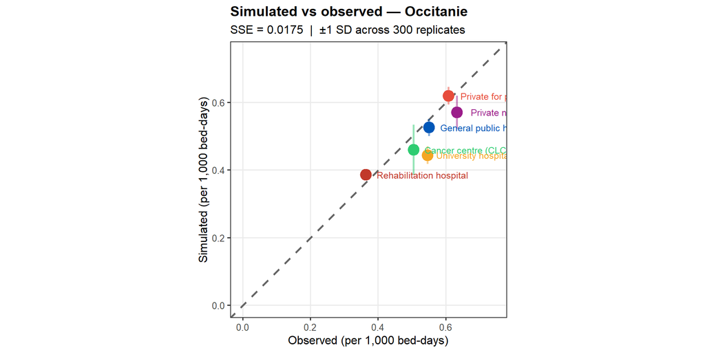

### Beta estimates

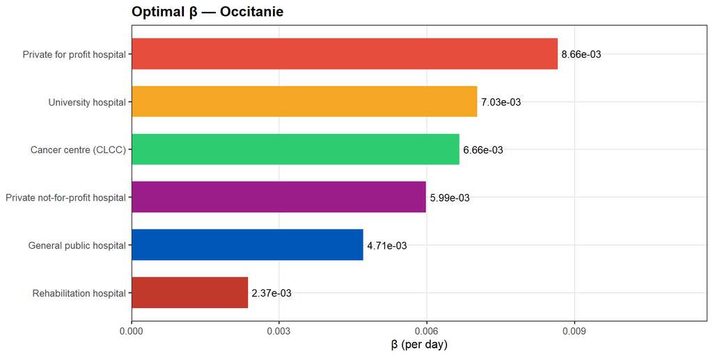

### Numerical summary

| Type | β | Observed | Sim mean | Sim SD | % error | SSE |
| --- | --- | --- | --- | --- | --- | --- |
| Cancer centre (CLCC) | 0.0067 | 0.5053 | 0.4598 | 0.0745 | -9.0 | 0.0021 |
| General public hospital | 0.0047 | 0.5502 | 0.5260 | 0.0259 | -4.4 | 0.0006 |
| Private for profit hospital | 0.0087 | 0.6083 | 0.6197 | 0.0262 | 1.9 | 0.0001 |
| Private not-for-profit hospital | 0.0060 | 0.6332 | 0.5709 | 0.0493 | -9.8 | 0.0039 |
| Rehabilitation hospital | 0.0024 | 0.3640 | 0.3860 | 0.0145 | 6.0 | 0.0005 |
| University hospital | 0.0070 | 0.5459 | 0.4441 | 0.0262 | -18.7 | 0.0104 |

## Pays de la Loire

**Hospitals in region:** 149 | **SSE:** 0.002457 | **Types:** Cancer centre (CLCC), General public hospital, Private for profit hospital, Private not-for-profit hospital, Rehabilitation hospital, University hospital

### Observed vs simulated incidence

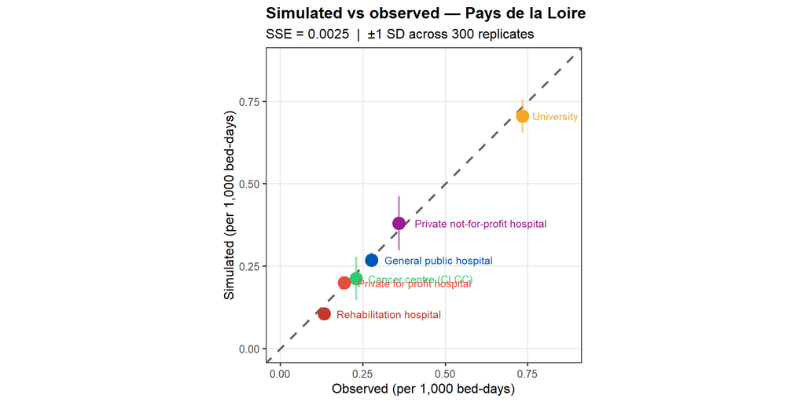

### Beta estimates

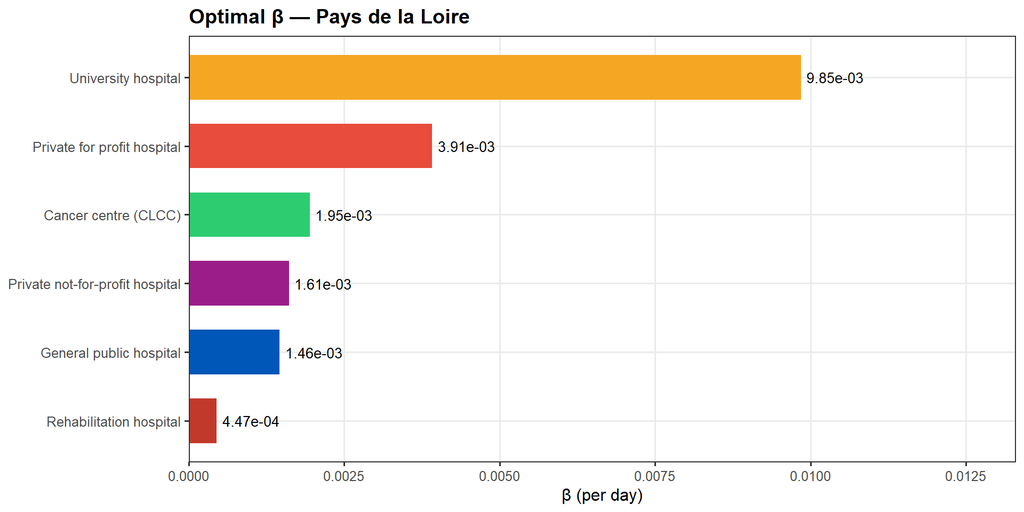

### Numerical summary

| Type | β | Observed | Sim mean | Sim SD | % error | SSE |
| --- | --- | --- | --- | --- | --- | --- |
| Cancer centre (CLCC) | 0.0019 | 0.2294 | 0.2121 | 0.0662 | -7.5 | 3e-04 |
| General public hospital | 0.0015 | 0.2767 | 0.2685 | 0.0221 | -3.0 | 1e-04 |
| Private for profit hospital | 0.0039 | 0.1940 | 0.1989 | 0.0103 | 2.6 | 0e+00 |
| Private not-for-profit hospital | 0.0016 | 0.3592 | 0.3800 | 0.0823 | 5.8 | 4e-04 |
| Rehabilitation hospital | 0.0004 | 0.1335 | 0.1053 | 0.0133 | -21.1 | 8e-04 |
| University hospital | 0.0098 | 0.7342 | 0.7051 | 0.0508 | -4.0 | 8e-04 |

## Provence-Alpes-Côte d’Azur

**Hospitals in region:** 262 | **SSE:** 0.080371 | **Types:** Cancer centre (CLCC), General public hospital, Private for profit hospital, Private not-for-profit hospital, Rehabilitation hospital, University hospital

### Observed vs simulated incidence

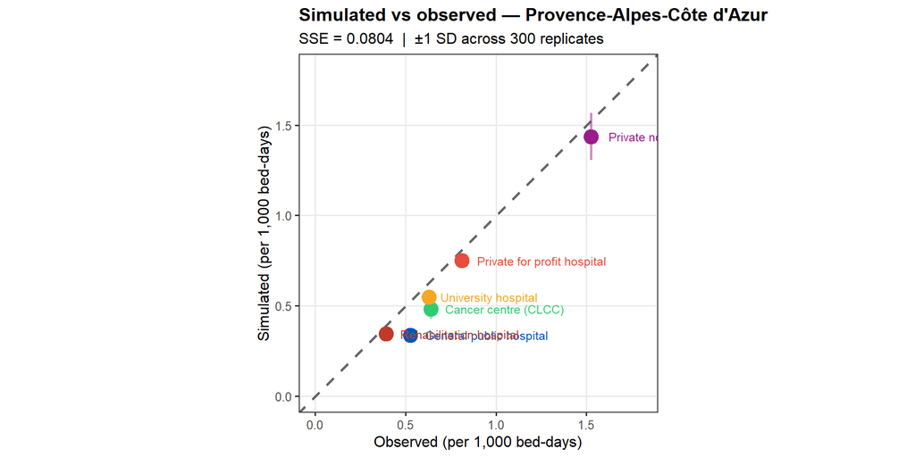

### Beta estimates

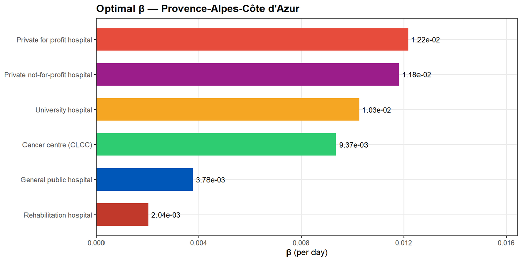

### Numerical summary

| Type | β | Observed | Sim mean | Sim SD | % error | SSE |
| --- | --- | --- | --- | --- | --- | --- |
| Cancer centre (CLCC) | 0.0094 | 0.6403 | 0.4831 | 0.0567 | -24.6 | 0.0247 |
| General public hospital | 0.0038 | 0.5259 | 0.3375 | 0.0267 | -35.8 | 0.0355 |
| Private for profit hospital | 0.0122 | 0.8111 | 0.7494 | 0.0220 | -7.6 | 0.0038 |
| Private not-for-profit hospital | 0.0118 | 1.5242 | 1.4366 | 0.1311 | -5.8 | 0.0077 |
| Rehabilitation hospital | 0.0020 | 0.3919 | 0.3450 | 0.0118 | -12.0 | 0.0022 |
| University hospital | 0.0103 | 0.6291 | 0.5485 | 0.0404 | -12.8 | 0.0065 |

*Report generated by ARCANE project — MESuRS/Cnam*